# Programming basics for Biostatistics 6099

Shiny for Python

Zhiguang Huo (Caleb)

Tue Oct 31st, 2023

# Outline

- Input controls
- Output controls
- Server logic (Reactive programming)
- Page layout

# Review how to deploy

reference: https://shiny.posit.co/py/docs/install.html

1. Open Anaconda,
   - create/select an environment
     - recommend a new environment
   - create a folder and go into the folder
2. In Python terminal, install the required packages

```
pip install --upgrade pip wheel
pip install shiny
pip install --upgrade shiny htmltools
```

3. In Python terminal, create a Python Shiny using the default

```
cd your_working_directory ## go to your working directory
shiny create . ## This will create a basic Shiny application in the current directory, in a file named app.py.
shiny run --reload
```

4. If the web application doesn’t show up, copy the URL into your browser (e.g., http://127.0.0.1:8000/)

# Input controls

- Number inputs
- Text inputs
- Selection inputs
- Toggle inputs
- Date inputs
- Action inputs

# Number inputs

```
from shiny import ui, App

app_ui = ui.page_fluid(
    ui.input_numeric("x1", "Number", value=10),
    ui.input_slider("x2", "Slider", value=10, min=0, max=20),
    ui.input_slider("x3", "Range slider", value=(6, 14), min=0, max=20)
)

app = App(app_ui, None)
```

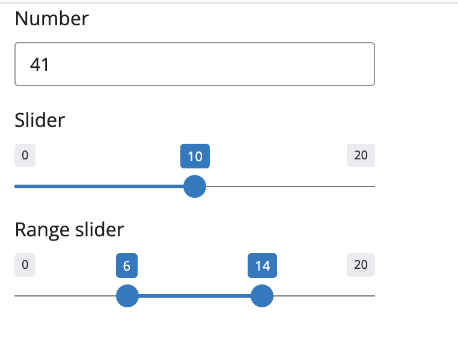

# Text inputs

```
from shiny import ui, App

app_ui = ui.page_fluid(
    ui.input_text("x1", "Text", placeholder="Enter text"),
    ui.input_text_area("x2", "Text area", placeholder="Enter text"),
    ui.input_password ("x3", "Password", placeholder="Enter password"),
)

app = App(app_ui, None)
```

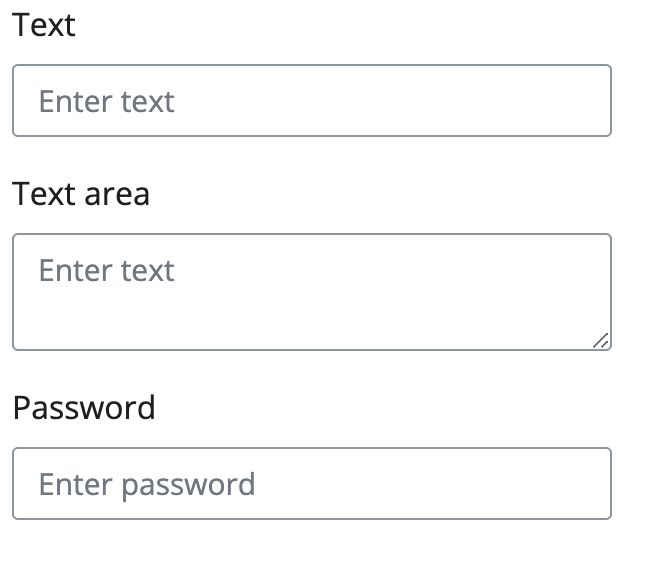

# Selection inputs

```
from shiny import ui, App

choices = ["apple", "banana", "cherry", "orange", "pear"]

app_ui = ui.page_fluid(
    ui.input_selectize("x1", "Selectize (single)", choices),
    ui.input_selectize("x2", "Selectize (multiple)", choices, multiple = True),
    ui.input_select("x3", "Select (single)", choices),
    ui.input_select("x4", "Select (multiple)", choices, multiple = True),
)

app = App(app_ui, None)
```

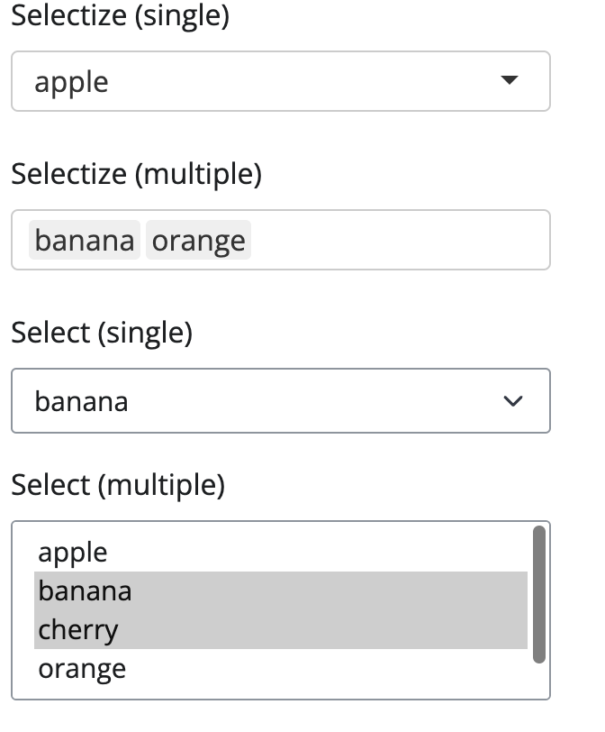

# Selection inputs (part 2)

```
from shiny import ui, App

choices = {"a": "Choice A", "b": "Choice B", "c": "Choice C"}

app_ui = ui.page_fluid(
    ui.input_radio_buttons("x1", "Radio buttons", choices),
    ui.input_checkbox_group("x2", "Checkbox group", choices),
)

app = App(app_ui, None)
```

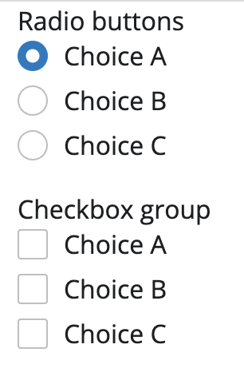

# Toggle inputs

```
from shiny import ui, App

app_ui = ui.page_fluid(
    ui.input_checkbox("x1", "Checkbox"),
    ui.input_switch("x2", "Switch")
)

app = App(app_ui, None)
```

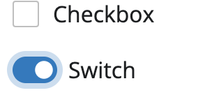

# Date inputs

```
from shiny import ui, App

app_ui = ui.page_fluid(
    ui.input_date("x1", "Date input"),
    ui.input_date_range("x2", "Date range input"),
)

app = App(app_ui, None)
```

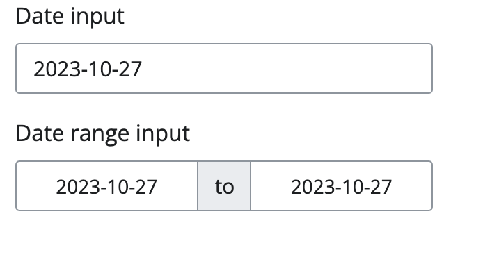

# Action input

```
from shiny import ui, App

app_ui = ui.page_fluid(
    ui.p(ui.input_action_button("x1", "Action button")),
    ui.p(ui.input_action_button("x2", "Action button", class_="btn-primary")),
    ui.p(ui.input_action_link("x3", "Action link")),
)

app = App(app_ui, None)
```

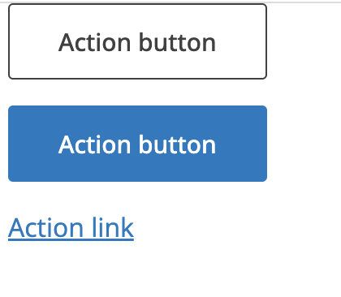

# Ouotput controls

- Text output
- Table output
- Plot output

# Text output

- decorate it with @render.text, to say the result is text (and not, e.g., an image).
- decorate it with @output, to say the result should be displayed on the web page.
- You could define multiple functions in the server.

```
from shiny import ui, render, App

app_ui = ui.page_fluid(
    ui.output_text("txt"),
    ui.output_text_verbatim("txt2"),
)

def server(input, output, session):
    @output
    @render.text
    def txt():
        return "text part 1"

    @output
    @render.text
    def txt2():
        return "text part 2"

# This is a shiny.App object. It must be named `app`.
app = App(app_ui, server)
```

# Table output

- Render various kinds of data frames into an HTML table with ui.output_table() and @render.table.

```python
import seaborn as sns
tips = sns.load_dataset("tips")
tips.head()
```

```
##    total_bill   tip     sex smoker  day    time  size
## 0       16.99  1.01  Female     No  Sun  Dinner     2
## 1       10.34  1.66    Male     No  Sun  Dinner     3
## 2       21.01  3.50    Male     No  Sun  Dinner     3
## 3       23.68  3.31    Male     No  Sun  Dinner     2
## 4       24.59  3.61  Female     No  Sun  Dinner     4
```

```
import pandas as pd
from shiny import ui, render, App
import seaborn as sns
tips = sns.load_dataset("tips")

app_ui = ui.page_fluid(
    ui.output_table("show_head"),
)

def server(input, output, session):
    @output
    @render.table
    def show_head():
        return tips[:10]

app = App(app_ui, server)
```

# Static plot output

- Render plots with ui.output_plot() and @render.plot
- Need to install the package before using them
  - matplotlib (this page)
  - seaborn (next page)

```
from shiny import ui, render, App
from matplotlib import pyplot as plt

app_ui = ui.page_fluid(
    ui.output_plot("plot_matplotlib"),
)

def server(input, output, session):
    @output
    @render.plot
    def plot_matplotlib():
        return plt.scatter([1,2,3], [5, 2, 3])

app = App(app_ui, server)
```

```
from shiny import ui, render, App
import seaborn as sns
tips = sns.load_dataset("tips")

app_ui = ui.page_fluid(
    ui.output_plot("scatter_seaborn"),
)

def server(input, output, session):
    @output
    @render.plot
    def scatter_seaborn():
        return sns.relplot(data=tips,x="total_bill", y="tip", kind='scatter')


app = App(app_ui, server)
```

# Reactive programming

- reactive.Value: An object that causes reactive functions to run when its value changes.
- reactive.Calc: Create a reactive function that is used for its return value.
- reactive.Effect: Create a reactive function that is used for its side effects (and not its return value).
- @output: outputs (wrapped up in a reactive.Effect) There are a few utility functions that help with managing reactivity:
- with isolate(): Run blocks of code inside a reactive function, but without taking a reactive dependency on code inside the block.
- @reactive.event(): A decorator that controls what causes a reactive function to invalidate.

# Reactive calculations

Sometimes we want to compute values based on inputs to avoid randomness

```
from shiny import ui, render, App
import random

app_ui = ui.page_fluid(
    ui.input_slider("n", "N", 0, 100, 40),
    ui.output_text_verbatim("txt1"),
    ui.output_text_verbatim("txt2"),
)

def server(input, output, session):
    @output
    @render.text
    def txt1():
        x1 = [ random.random() for i in range(input.n())]
        return f"The mean of {input.n()} random values is {sum(x1)/len(x1)}"

    @output
    @render.text
    def txt2():
        x2 = [ random.random() for i in range(input.n())]
        return f"The mean of {input.n()} random values is {sum(x2)/len(x2)}"


# This is a shiny.App object. It must be named `app`.
app = App(app_ui, server)
```

# Reactive calculations

- need to import reactive from shiny package
- @reactive.Calc will cache the intermediate result and guarantee consistency
- try a function without @reactive.Calc

```
from shiny import ui, render, reactive, App
import random

app_ui = ui.page_fluid(
    ui.input_slider("n", "N", 0, 100, 40),
    ui.output_text_verbatim("txt1"),
    ui.output_text_verbatim("txt2"),
)



def server(input, output, session):
    @reactive.Calc
    def get_mean():
        x = [ random.random() for i in range(input.n())]
        return sum(x)/len(x)

    @output
    @render.text
    def txt1():
        return f"The mean of {input.n()} random values is {get_mean()}"

    @output
    @render.text
    def txt2():
        return f"The mean of {input.n()} random values is {get_mean()}"


# This is a shiny.App object. It must be named `app`.
app = App(app_ui, server)
```

# Handling events

- prevent auto update: reactive.event()
  - This decorator takes one or more reactive dependency that cause the decorated function to re-execute.

```
from shiny import App, reactive, render, ui

app_ui = ui.page_fluid(
    ui.input_slider("n", "N", min=1, max=100, value=1),
    ui.input_action_button("compute", "Compute!"),
    ui.output_text_verbatim("result", placeholder=True),
)

def server(input, output, session):

    @output
    @render.text
    @reactive.event(input.compute) # Take a dependency on the button
    def result():
        # Because of the @reactive.event(), everything in this function is
        # ignored until reactive dependencies are triggered.
        return f"Result: {input.n()}"

app = App(app_ui, server)
```

# Handling events

- prevent auto update: reactive.isolate()
  - Using with isolate(), a block of code won’t run until a reactive dependency is triggered.
  - the reactive dependency should be in the same function of the reactive.isolate()

```
from shiny import App, reactive, render, ui

app_ui = ui.page_fluid(
    ui.input_slider("n", "N", min=1, max=100, value=1),
    ui.input_action_button("compute", "Compute!"),
    ui.output_text_verbatim("result", placeholder=True),
)

def server(input, output, session):

    @output
    @render.text
    def result():
        input.compute()    # Take a dependency on the button

        with reactive.isolate():
            return f"Result: {input.n()}"

app = App(app_ui, server)
```

# Reactive values

- reactive.Value: an intermediate variable in Shiny app
  - @reactive.Effect: declare that there is a reactive effect
  - x = reactive.Value()
    - x() or x.get(): get values
    - x.set(): to use this function to set values

```
from shiny import App, reactive, render, ui

app_ui = ui.page_fluid(
    ui.input_action_button("toggle", "Toggle value"),
    ui.output_text_verbatim("txt"),
)

def server(input, output, session):
    x = reactive.Value(True)

    @reactive.Effect
    @reactive.event(input.toggle)
    def _():
        x.set(not x())

    @output
    @render.text
    def txt():
        return str(x())

app = App(app_ui, server)
```

# Example of reactive values (1)

- user_provided_values is not a reactive value

```
from shiny import App, reactive, render, ui

app_ui = ui.page_fluid(
    ui.input_numeric("x", "Enter a value to add to the list:", 1),
    ui.input_action_button("submit", "Add Value"),
    ui.p(
        ui.output_text_verbatim("out")
    ),
)

def server(input, output, session):
    # Stores all the values the user has submitted so far
    user_provided_values = []

    @reactive.Effect
    @reactive.event(input.submit)
    def add_value_to_list():
        values = user_provided_values()
        values.append(input.x())

    @output
    @render.text
    def out():
        return f"Values: {user_provided_values()}"

app = App(app_ui, server)
```

# Example of reactive values (2)

- user_provided_values can only be modified by set

```
from shiny import App, reactive, render, ui

app_ui = ui.page_fluid(
    ui.input_numeric("x", "Enter a value to add to the list:", 1),
    ui.input_action_button("submit", "Add Value"),
    ui.p(
        ui.output_text_verbatim("out")
    ),
)

def server(input, output, session):
    # Stores all the values the user has submitted so far
    user_provided_values = reactive.Value([])

    @reactive.Effect
    @reactive.event(input.submit)
    def add_value_to_list():
        values = user_provided_values()
        values.append(input.x())

    @output
    @render.text
    def out():
        return f"Values: {user_provided_values()}"

app = App(app_ui, server)
```

# Example of reactive values (3)

- a working example

```
from shiny import App, reactive, render, ui

app_ui = ui.page_fluid(
    ui.input_numeric("x", "Enter a value to add to the list:", 1),
    ui.input_action_button("submit", "Add Value"),
    ui.p(
        ui.output_text_verbatim("out")
    ),
)

def server(input, output, session):
    # Stores all the values the user has submitted so far
    user_provided_values = reactive.Value([])

    @reactive.Effect
    @reactive.event(input.submit)
    def add_value_to_list():
        user_provided_values.set(user_provided_values() + [input.x()])

    @output
    @render.text
    def out():
        return f"Values: {user_provided_values()}"

app = App(app_ui, server)
```

# page layouts

- a common setup for shiny apps:
  - page_* is the outermost piece. page_fluid means it will expand to fill the full width of the browser window, rather than stopping at a certain width.
  - layout_* positions the pieces inside it (e.g. put them side-by-side).
  - panel_* is used for a range of common pieces used in shiny apps.

```
app_ui = ui.page_fluid(
    ui.panel_title(),
    ui.layout_sidebar(
        ui.panel_sidebar(
            ...
        ),
        ui.panel_main(
            ...
        ),
    ),
)
```

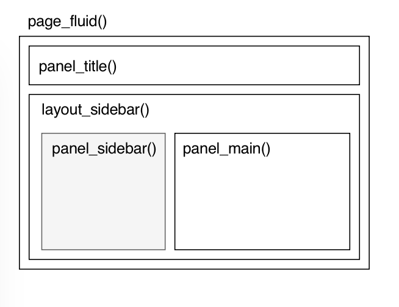

# Page with sidebar

```
from shiny import App, render, ui
import matplotlib.pyplot as plt
import numpy as np

app_ui = ui.page_fluid(
    ui.panel_title("Simulate a normal distribution"),

    ui.layout_sidebar(

      ui.panel_sidebar(
        ui.input_slider("n", "Sample size", 0, 1000, 250),
        ui.input_numeric("mean", "Mean", 0),
        ui.input_numeric("std_dev", "Standard deviation", 1),
        ui.input_slider("n_bins", "Number of bins", 0, 100, 20),
      ),

      ui.panel_main(
        ui.output_plot("plot")
      ),
    ),
)


def server(input, output, session):

    @output
    @render.plot(alt="A histogram")
    def plot():
        x = np.random.normal(input.mean(), input.std_dev(), input.n())

        fig, ax = plt.subplots()
        ax.hist(x, input.n_bins(), density=True)
        return fig


app = App(app_ui, server)
```

# Adding rows and columns

```
from shiny import App, ui

style="border: 1px solid #999;"

app_ui = ui.page_fluid(
    ui.row(
        ui.column(4, "row-1 col-1", style=style),
        ui.column(8, "row-1 col-2", style=style),
    ),
    ui.row(
        ui.column(6, "row-2 col-1", style=style),
        ui.column(6, "row-2 col-2", style=style),
    ),
)


app = App(app_ui, None)
```

# Styling Shiny apps

- 25 themes in shinyswatch: https://github.com/posit-dev/py-shinyswatch/blob/main/shinyswatch/theme.py
  - Dark theme: shinyswatch.darkly()
  - Minty theme: shinyswatch.theme.minty()
  - Sketchy theme: shinyswatch.theme.sketchy()
  - Superhero theme: shinyswatch.theme.superhero()

```
from shiny import App, Inputs, Outputs, Session, render, ui

import shinyswatch

app_ui = ui.page_fluid(
    shinyswatch.theme.darkly(),
    ui.input_slider("num", "Number:", min=10, max=100, value=30),
    ui.output_text_verbatim("slider_val"),
)


def server(input: Inputs, output: Outputs, session: Session):
    @output
    @render.text
    def slider_val():
        return f"{input.num()}"


app = App(app_ui, server)
```

- customize your own style (if you know about css):

```
ui.page_fluid(
    ui.include_css("my-styles.css")
  )
```

# Tabs and navigation

- a navset_*() style container that determines what the navigation will look like.
- nav_*() elements that create different pieces of content.
  - Tabs: ui.navset_tab
  - Pills: ui.navset_pill
  - Lists: ui.navset_pill_list
  - Tabs: ui.navset_tab

```
from shiny import App, ui

app_ui = ui.page_fluid(
    ui.navset_tab(
        ui.nav("a", "tab a content"),
        ui.nav("b", "tab b content"),
        # ui.nav_control("c"), ## no content
    )
)

app = App(app_ui, None)
```

# Menus

```
from shiny import App, ui

app_ui = ui.page_fluid(
    ui.navset_tab_card(
       ui.nav("a", "tab a content"),
       ui.nav_menu(
           "Other links",

           # body of menu
           ui.nav("b", "tab b content"),
           "Plain text",

           # create a horizontal line
           "----",

           "More text",
           align="right",
       ),
  )
)

app = App(app_ui, None)
```

# References:

- https://shiny.posit.co/py/docs/overview.html
- https://shiny.posit.co/py/docs/install.html